# Phase 3: DRY PEAS Agricultural Commodity Loss Variations across the Pacific Northwest Palouse Region, 1989-2015 - Mixed Modeling Analysis

Erich Seamon

9/25/2018

## Introduction

This analysis explores the relationships of agricultural commodity loss, at a county level, from 1989-2015, for the 26 county region of the Palouse, in Washington, Idaho, and Oregon. Here we explore the entire range of commodities and damage causes, identifying the top revenue loss commodities and their most pertinent damage causes - as indicated from the USDA’s agricultural commodity loss insurance archive.

In Phase 3, we perform a DRY PEAS mixed modeling analysis using a two-step hurdle technique for a selected set of damage causes. The following analysis builds on Phases 1 and 2, steps 1-10.

**Step 11.** DRY PEAS Commodity Mixed Model Analysis. In Step 11, we perform a DRY PEAS mixed modeling analysis, using a two step hurdle model technique to address zero-inflated data.

Hurdle model techniques allow us to address zero inflated datasets, by first running a logstical regression model to determine the probability of zeros occuring. Then we use the non-zero values in a separate, mixed model. In this instance, we use county as a random effect.

As such, these are not missing data, but actual zero values that we do not want to exclude from our model. However we want to be able to use a normalized distribution that is not positively skewed/zero inflated.

## Hurdle Model - DRY PEAS

Here we run our hurdle technique for DRY PEAS, using a generalized linear model with a binomal function to delineate between zero and non-zero values. Given this model, Is our data normally distributed? What (if any) outliers exist? Are residuals well distributed - indicating normality?

```
##           llh       llhNull            G2      McFadden          r2ML
##  -679.8268582 -1138.2908423   916.9279682     0.4027652     0.3620367
##          r2CU
##     0.5384221
```

```
##
##  Hosmer and Lemeshow goodness of fit (GOF) test
##
## data:  alllevs2_drypeas$non_zero, fitted(m1)
## X-squared = 9.2597, df = 8, p-value = 0.3209
```

**FIGURE 12:** Dry Peas Non-zero Goodness of fit hoslem test

Now plot this Dry Peas zero/non-zero bionomal model to see outliers and the zeros vs non-zeros.

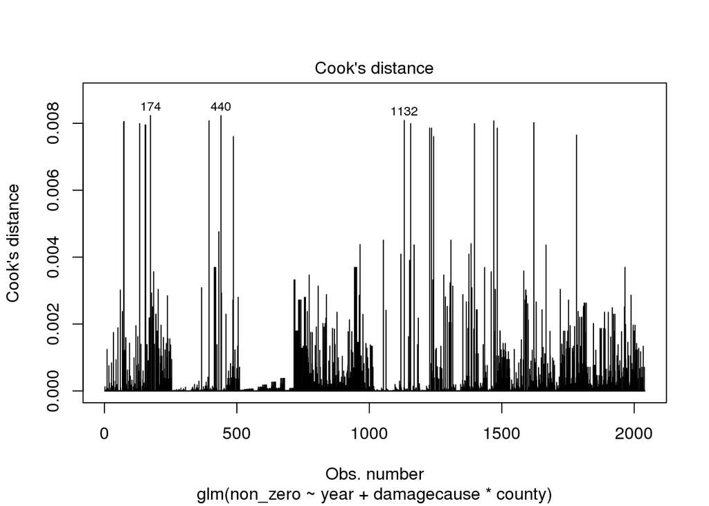

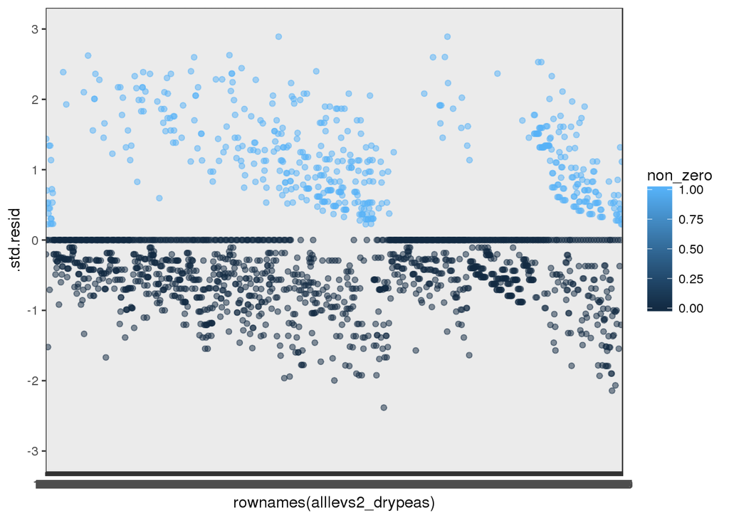

**FIGURE 13:** Dry Peas zero/non-zero bionomal model to see outliers and zeros values vs non-zero values.

### Checking for multi collinearity

```
##                    GVIF  Df GVIF^(1/(2*Df))
## year                NaN  14             NaN
## damagecause         NaN   7             NaN
## county              NaN  16             NaN
## damagecause:county  NaN 112             NaN
```

**FIGURE 14:** Dry Peas multi-collinearity test for our binomal model.

```
##
## Call:
## glm(formula = non_zero ~ year + damagecause * county, family = binomial(link = logit),
##     data = alllevs2_drypeas)
##
## Deviance Residuals:
##      Min        1Q    Median        3Q       Max
## -2.35061  -0.56960  -0.20076  -0.00002   2.86220
##
## Coefficients:
##                                                 Estimate Std. Error
## (Intercept)                                   -3.894e+00  1.104e+00
## year2002                                       4.163e-01  4.093e-01
## year2003                                       5.682e-01  4.052e-01
## year2004                                      -1.251e+00  4.957e-01
## year2005                                       9.201e-01  3.971e-01
## year2006                                       1.179e+00  3.924e-01
## year2007                                       6.416e-01  4.033e-01
## year2008                                       1.422e+00  3.890e-01
## year2009                                       7.133e-01  4.016e-01
## year2010                                       1.654e+00  3.865e-01
## year2011                                      -1.850e-01  4.304e-01
## year2012                                       7.133e-01  4.016e-01
## year2013                                       1.985e+00  3.845e-01
## year2014                                       2.412e+00  3.847e-01
## year2015                                       2.359e+00  3.845e-01
## damagecauseCold Winter                        -1.686e+01  2.614e+03
## damagecauseDecline in Price                   -1.686e+01  2.614e+03
## damagecauseDrought                             2.158e+00  1.216e+00
## damagecauseFreeze                             -1.686e+01  2.614e+03
## damagecauseFrost                              -1.686e+01  2.614e+03
## damagecauseHail                                8.209e-01  1.325e+00
## damagecauseHeat                                1.787e+00  1.233e+00
## countyBenewah                                  2.497e+00  1.207e+00
## countyClearwater                               5.266e-14  1.500e+00
## countyColumbia                                 4.326e-14  1.500e+00
## countyGarfield                                 2.547e-14  1.500e+00
## countyGrant                                    6.770e-14  1.500e+00
## countyIdaho                                    1.787e+00  1.233e+00
## countyKootenai                                 1.787e+00  1.233e+00
```

[output cut: 267 more lines]

```
## damagecauseDrought:countyWhitman               -0.732 0.464127
## damagecauseFreeze:countyWhitman                 0.005 0.996130
## damagecauseFrost:countyWhitman                  0.006 0.995471
## damagecauseHail:countyWhitman                  -0.975 0.329327
## damagecauseHeat:countyWhitman                  -0.871 0.383744
## ---
## Signif. codes:  0 '***' 0.001 '**' 0.01 '*' 0.05 '.' 0.1 ' ' 1
##
## (Dispersion parameter for binomial family taken to be 1)
##
##     Null deviance: 2276.6  on 2039  degrees of freedom
## Residual deviance: 1359.7  on 1890  degrees of freedom
## AIC: 1659.7
##
## Number of Fisher Scoring iterations: 18
```

**FIGURE 14:** Dry Peas binomal model summary

## Now subset to just those Dry Peas observations with a loss greater than zero (so all non-zeros), and run a linear regression (switched to log loss due to outliers), to make sure that our residuals and other parameters suggest normality.

```
## Linear mixed model fit by REML ['lmerMod']
## Formula: log(loss) ~ year + damagecause + (1 | county)
##    Data: subset(alllevs2_drypeas, non_zero == 1)
##
## REML criterion at convergence: 1860
##
## Scaled residuals:
##     Min      1Q  Median      3Q     Max
## -3.9544 -0.4928  0.1551  0.6655  2.1097
##
## Random effects:
##  Groups   Name        Variance Std.Dev.
##  county   (Intercept) 0.3996   0.6321
##  Residual             2.2811   1.5103
## Number of obs: 502, groups:  county, 17
##
## Fixed effects:
##                             Estimate Std. Error t value
## (Intercept)                   6.4011     0.4337  14.758
## year2002                      1.1477     0.4605   2.492
## year2003                      1.7577     0.4493   3.912
## year2004                      1.6750     0.6272   2.670
## year2005                      2.2060     0.4360   5.059
## year2006                      1.3581     0.4271   3.180
## year2007                      1.6262     0.4486   3.625
## year2008                      2.4535     0.4210   5.828
## year2009                      1.8246     0.4456   4.095
## year2010                      2.3902     0.4191   5.703
## year2011                      2.0400     0.5166   3.949
## year2012                      2.2563     0.4510   5.003
## year2013                      2.4718     0.4136   5.977
## year2014                      2.9396     0.4059   7.243
## year2015                      3.8526     0.4023   9.577
## damagecauseCold Winter       -0.6207     0.4355  -1.425
## damagecauseDecline in Price  -0.4614     0.3677  -1.255
## damagecauseDrought            0.4783     0.2587   1.849
## damagecauseFreeze            -0.9689     0.4255  -2.277
## damagecauseFrost             -0.2361     0.3297  -0.716
## damagecauseHail               0.3804     0.2905   1.309
## damagecauseHeat               0.2298     0.2515   0.914
```

**FIGURE 45:** Dry Peas mixed model coefficient estimates for damage cause and year.

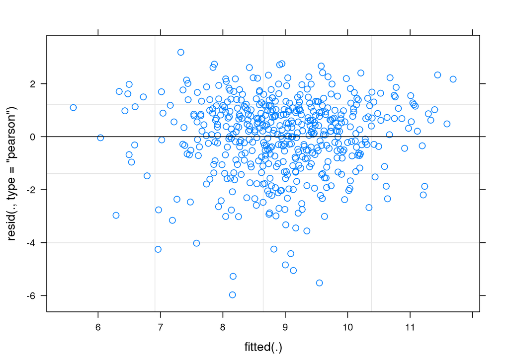

# Finally, we examine the DRY PEAS coefficent estimates of our model output.

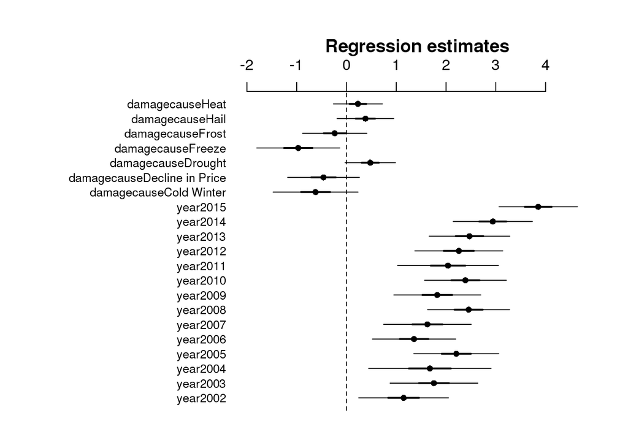

**FIGURE 47:** Dry Peas mixed model coefficient estimates for damage cause and year.

**FIGURE 19:** Dry Peas mixed model coefficient estimates.

# Finally, we exponentiate the coefficient estimates and confidence intervals for odds ratios.

```
##                              rn      lower       upper   estimate stderror
##  1:                    year2002  1.3017723   7.6412632  3.1510220 1.584912
##  2:                    year2003  2.4469410  13.7523548  5.7990471 1.567200
##  3:                    year2004  1.6018655  17.8527384  5.3388800 1.872447
##  4:                    year2005  3.9293215  20.9850703  9.0796703 1.546574
##  5:                    year2006  1.7129457   8.8396657  3.8887481 1.532749
##  6:                    year2007  2.1497273  12.0563155  5.0844397 1.566053
##  7:                    year2008  5.1830773  26.1285021 11.6295078 1.523426
##  8:                    year2009  2.6352492  14.5996543  6.2000068 1.561365
##  9:                    year2010  4.8811790  24.4259125 10.9157261 1.520577
## 10:                    year2011  2.8537106  20.8210658  7.6903393 1.676387
## 11:                    year2012  4.0176232  22.7341095  9.5473067 1.569822
## 12:                    year2013  5.3546238  26.2384348 11.8432900 1.512191
## 13:                    year2014  8.6741820  41.2573245 18.9087670 1.500614
## 14:                    year2015 21.7649829 102.1191780 47.1175633 1.495241
## 15:      damagecauseCold Winter  0.2330977   1.2458334  0.5375878 1.545689
## 16: damagecauseDecline in Price  0.3109437   1.2771526  0.6304087 1.444388
## 17:          damagecauseDrought  0.9812936   2.6511404  1.6132606 1.295214
## 18:           damagecauseFreeze  0.1677002   0.8607936  0.3795095 1.530426
## 19:            damagecauseFrost  0.4194035   1.4890046  0.7897253 1.390562
## 20:             damagecauseHail  0.8377201   2.5599627  1.4629353 1.337147
## 21:             damagecauseHeat  0.7758169   2.0391972  1.2582955 1.285938
##                              rn      lower       upper   estimate stderror
```

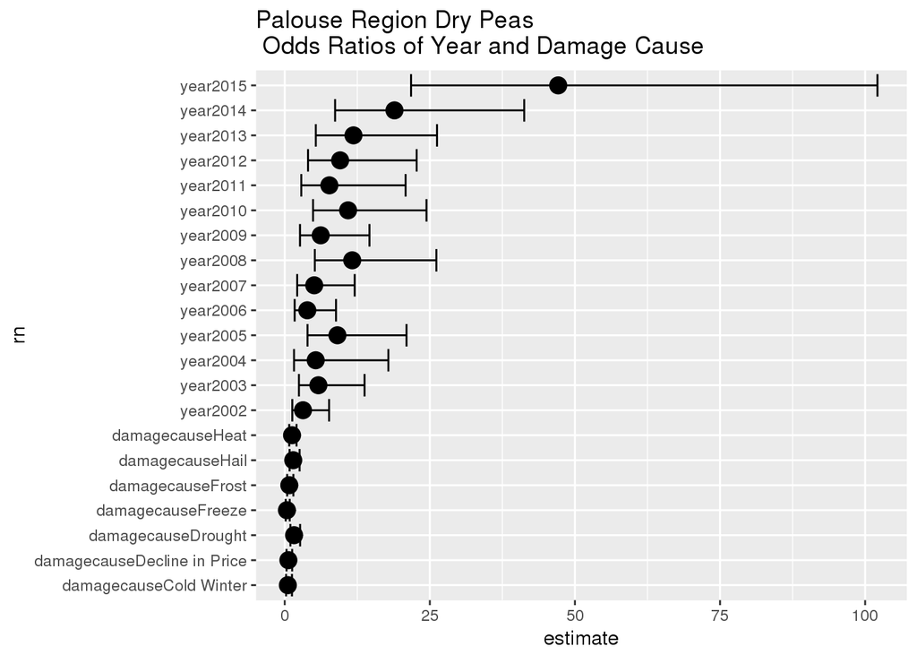